# Pandas-Bootcamp-Part12

### HISTOGRAMS

https://www.udemy.com/course/the-ultimate-pandas-bootcamp-advanced-python-data-analysis/learn/lecture/19512848#overview

```python
drinks = pd.read_csv('drinks.csv')
```

Histograms are charts that plot the distribution of a Numeric value as a Series of bars.

- Each of the bars cover a fixed range of values that is called the Bin-Size.
- And the height of the bar indicate the frequency of values that falls in that bin size
- We use Histograms when we are interested in understanding how a given numerical field is distributed
- With Histograms we are trying to answer questions like , In what range do the most common values fall
- Or is the distribution Left or Right Skewed
- Are there one or two modes or peaks

```python
drinks.head(2)
```

|  | country | beer_servings | spirit_servings | wine_servings | total_litres_of_pure_alcohol |
| --- | --- | --- | --- | --- | --- |
| 0 | Afghanistan | NaN | NaN | NaN | NaN |
| 1 | Albania | 89.0 | 132.0 | 54.0 | 4.9 |

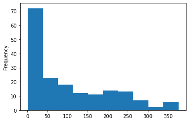

```python
drinks.beer_servings.plot(kind= 'hist');
```

- Most countries have between 0 and 50 beer servings
- We know this because , we can see that the tallest bar is between 0 to 50 range

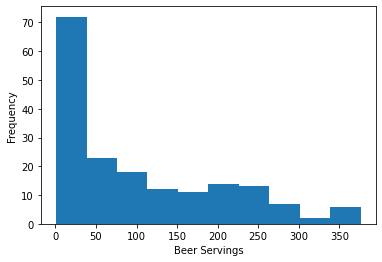

```python
#Lets give x-axis Label
#Lets get a handle on the axes object
ax = drinks.beer_servings.plot(kind= 'hist');
ax.set_xlabel('Beer Servings');
```

#### How wide should the Bins be?

Its really something that we should determine when we Analyse the data and understand it better

```python
#The default bin size is 10 in Matplotlib
#Bin size or Number of Bins
```

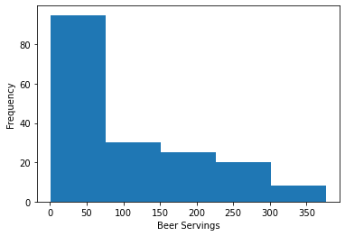

```python
#With bin size = 5 , we have lost some level of detail
ax = drinks.beer_servings.plot(kind= 'hist' , bins = 5);
ax.set_xlabel('Beer Servings');
```

- As we increase the number of Beer Servings , the number of countries in each bin monotonously decreases

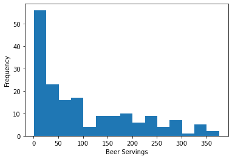

```python
ax = drinks.beer_servings.plot(kind= 'hist' , bins = 15);
ax.set_xlabel('Beer Servings');
```

- Now if we change the bin size , it still implies that as we increase the number of Beer Servings , the number of countries decreases, but its not as monotonous as we first thought.

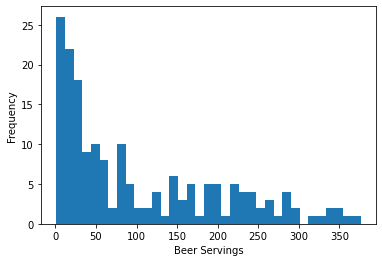

```python
ax = drinks.beer_servings.plot(kind= 'hist' , bins = 35);
ax.set_xlabel('Beer Servings');
```

- The distribution starts to get very rough
- Perhaps there is a lot of noise here to freally infer much insight
- Its upto us to understand our data better and plot the required bin size

Note : Not too much noise and enough detail are important aspects to be taken care of

#### Changing the Orientation of the Plot

```python
#Horizontal
```

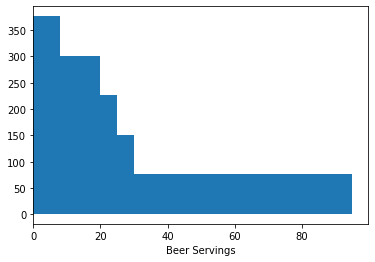

```python
ax = drinks.beer_servings.plot(kind= 'hist' , bins = 5 , orientation = 'horizontal');
ax.set_xlabel('Beer Servings');
```

### Calling histogram on the whole DataFrame instead of Series

```python
#We start by selecting all the Rows and columns : "beer_servings" to "wine_servings"
```

```python
drinks.head(2)
```

|  | country | beer_servings | spirit_servings | wine_servings | total_litres_of_pure_alcohol |
| --- | --- | --- | --- | --- | --- |
| 0 | Afghanistan | NaN | NaN | NaN | NaN |
| 1 | Albania | 89.0 | 132.0 | 54.0 | 4.9 |

```python
#we get the DataFrame Slice
drinks.loc[: , 'beer_servings' : 'wine_servings']
```

|  | beer_servings | spirit_servings | wine_servings |
| --- | --- | --- | --- |
| 0 | NaN | NaN | NaN |
| 1 | 89.0 | 132.0 | 54.0 |
| 2 | 25.0 | NaN | 14.0 |
| 3 | 245.0 | 138.0 | 312.0 |
| 4 | 217.0 | 57.0 | 45.0 |
| ... | ... | ... | ... |
| 188 | 333.0 | 1.0 | 3.0 |
| 189 | 111.0 | 2.0 | 1.0 |
| 190 | 6.0 | NaN | NaN |
| 191 | 32.0 | 19.0 | 4.0 |
| 192 | 64.0 | 18.0 | 4.0 |

193 rows × 3 columns

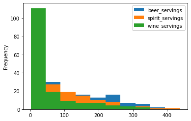

```python
drinks.loc[: , 'beer_servings' : 'wine_servings'].plot(kind = 'hist');
```

- We see all three column values in the same plot
- This isa bit misleading
- Te distributions overlapped significantly and are overshadowing one another

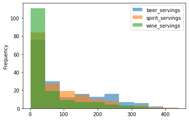

```python
#We change the Opacity
drinks.loc[: , 'beer_servings' : 'wine_servings'].plot(kind = 'hist' , alpha = 0.6);
```

- It still feels like an overloaded histogram

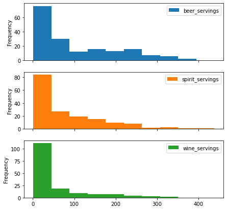

```python
drinks.loc[: , 'beer_servings' : 'wine_servings'].plot(kind = 'hist' , subplots = True , figsize = (7,7));
```

### Scatter plot

```python
sat = pd.read_csv('scores.csv')
```

```python
sat.head(2)
```

|  | School Name | Borough | Student Enrollment | Percent Tested | SAT Section | Score |
| --- | --- | --- | --- | --- | --- | --- |
| 0 | A. Philip Randolph Campus High School | Manhattan | 1354 | 74.00% | Math | 459 |
| 1 | A. Philip Randolph Campus High School | Manhattan | 1354 | 74.00% | Reading | 453 |

https://www.udemy.com/course/the-ultimate-pandas-bootcamp-advanced-python-data-analysis/learn/lecture/19513476#overview

Just like Histograms , Scatterplots are also used with Numeric values. But instead of helping us understand the Distribution of a Single variable, Scatterplots help highlight the relationship between two variables.

#### How good is the relationship between different Sections in the SAT section.

(Math , Reading , Writing)

#### Hypothesis : Reading and Writing are more strongly associated than writing and Math ?

```
Is this hypothesis supported by our Dataset?
```

```python
#For this we need to reshape data
#We first need rto isolate the individual section scores in separate Series so that we have nice sequences of values
#representing only the Scores that we are about to Plot
```

```python
math = sat[sat['SAT Section'] == 'Math']
```

```python
math.head(3)
```

|  | School Name | Borough | Student Enrollment | Percent Tested | SAT Section | Score |
| --- | --- | --- | --- | --- | --- | --- |
| 0 | A. Philip Randolph Campus High School | Manhattan | 1354 | 74.00% | Math | 459 |
| 3 | Abraham Lincoln High School | Brooklyn | 2341 | 54.90% | Math | 441 |
| 6 | Academy for Careers in Television and Film | Queens | 515 | 95.00% | Math | 444 |

```python
#From this resulting Dataframe we will select the Score column
math = sat[sat['SAT Section'] == 'Math'].Score.reset_index(drop = True)
```

```python
#We now have Single sequence of values containing the SAT Math section scores from all high schools
#in New York City
math
```

```
0      459
1      441
2      444
3      386
4      381
      ...
370    484
371    496
372    478
373    483
374    415
Name: Score, Length: 375, dtype: int64
```

```python
#Lets do the same for "Reading" and "Writing"
math = sat[sat['SAT Section'] == 'Math'].Score.reset_index(drop = True)
writing = sat[sat['SAT Section'] == 'Writing'].Score.reset_index(drop = True)
reading = sat[sat['SAT Section'] == 'Reading'].Score.reset_index(drop = True)
```

```python
writing.head()
```

```
0    447
1    422
2    444
3    393
4    390
Name: Score, dtype: int64
```

#### Now that we have separate Series , Lets concatenate them in one DataFrame

```python
#We need to Modify the Column Labels
pd.concat([math , writing, reading] , axis = 1)
```

|  | Score | Score | Score |
| --- | --- | --- | --- |
| 0 | 459 | 447 | 453 |
| 1 | 441 | 422 | 422 |
| 2 | 444 | 444 | 458 |
| 3 | 386 | 393 | 397 |
| 4 | 381 | 390 | 397 |
| ... | ... | ... | ... |
| 370 | 484 | 487 | 491 |
| 371 | 496 | 473 | 481 |
| 372 | 478 | 472 | 465 |
| 373 | 483 | 477 | 464 |
| 374 | 415 | 433 | 420 |

375 rows × 3 columns

```python
scores = pd.concat([math , writing, reading] , axis = 1)
scores.columns = ['Math' , 'Writing' , 'Reading']
```

```python
scores.head(2)
```

|  | Math | Writing | Reading |
| --- | --- | --- | --- |
| 0 | 459 | 447 | 453 |
| 1 | 441 | 422 | 422 |

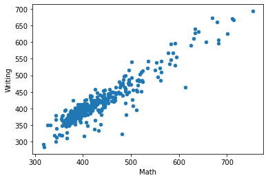

```python
scores.plot(kind = 'scatter' , x= 'Math' , y = 'Writing');
```

- There seems to be a Strong Positive Relationship between Math and Writing Scores.
- Higher Math Scores are associated with higher Writing Scores
- Lets calculate the Correlation

```python
math.corr(writing)
```

```
0.9341552744743187
```

- Math scores are Sytrongly positively related to Writing Scores

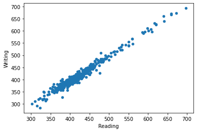

```python
scores.plot(kind = 'scatter' , x= 'Reading' , y ='Writing')
```

- There seems to be a Strong Positive Correlation
- There is also lesser variability around the correlation line compared to what we saw with "Math" above
- There are fewer outliers

```python
reading.corr(writing)
```

```
0.9854389581058107
```

- Almost 0.99 Correlation which is veryclose to perfect Positive Correlation which is indicated by 1

#### Conclusion :

- The Average SAT section scores across New York City High schools are on average Strongly positively associated, with "Reading" and "Writing" much more positively correlated compared to "Writing" and "Math"

### Other Visualization Options

### Seaborn works very well with Pandas

```python
#To check if the Seaborn package is available
!pip show seaborn
```

```
Name: seaborn
Version: 0.10.1
Summary: seaborn: statistical data visualization
Home-page: https://seaborn.pydata.org
Author: Michael Waskom
Author-email: mwaskom@nyu.edu
License: BSD (3-clause)
Location: c:\users\aisha\anaconda3\lib\site-packages
Requires: numpy, scipy, matplotlib, pandas
Required-by: pycaret, pandas-profiling, missingno
```

```python
import seaborn as sns
```

```python
scores.head()
```

|  | Math | Writing | Reading |
| --- | --- | --- | --- |
| 0 | 459 | 447 | 453 |
| 1 | 441 | 422 | 422 |
| 2 | 444 | 444 | 458 |
| 3 | 386 | 393 | 397 |
| 4 | 381 | 390 | 397 |

#### JOINT PLOT :

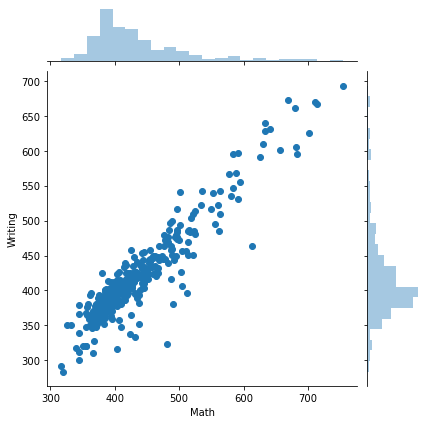

```python
sns.jointplot('Math' , 'Writing' , scores , kind = "scatter");
```

#### Hexagonal Binning

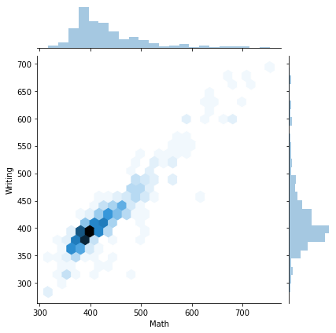

```python
sns.jointplot('Math' , 'Writing' , scores , kind = "hex");
```

Matplotlib is a highly resilient Choice

- Learn Seaborn as well
- Plotly and bokeh let you create Interactive graphs

### Skill Challenge

```python
games = pd.read_csv('games_sales.csv')
```

#### Starting with games dataset , create a PIE plot that breaks down "total game sales" (Global Sales) by gaming console (Platform).

```python
games.head(2)
```

|  | Name | Platform | Year | Genre | Publisher | NA_Sales | EU_Sales | JP_Sales | Other_Sales | Global_Sales |
| --- | --- | --- | --- | --- | --- | --- | --- | --- | --- | --- |
| 0 | Kinect Adventures! | X360 | 2010.0 | Misc | Microsoft Game Studios | 14.97 | 4.94 | 0.24 | 1.67 | 21.82 |
| 1 | Grand Theft Auto V | PS3 | 2013.0 | Action | Take-Two Interactive | 7.01 | 9.27 | 0.97 | 4.14 | 21.40 |

```python
games[['Platform' , 'Global_Sales']].set_index('Platform').groupby('Platform').sum()
```

| Platform | Global_Sales |
| --- | --- |
| PS3 | 957.84 |
| PS4 | 278.10 |
| X360 | 979.96 |
| XOne | 141.06 |

```python
platform = games[['Platform' , 'Global_Sales']].set_index('Platform').groupby('Platform').sum()
```

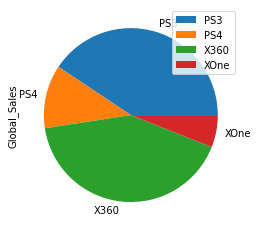

```python
platform.plot(kind = 'pie' , y = 'Global_Sales');
```

#### From the games dataset, create a smaller dataset that contains total Global_Sales across platforms from all releases in the sports Genre. Set "Name" as the index of this new Dataframe and assign it to the variable sports_games.

```python
games.head(2)
```

|  | Name | Platform | Year | Genre | Publisher | NA_Sales | EU_Sales | JP_Sales | Other_Sales | Global_Sales |
| --- | --- | --- | --- | --- | --- | --- | --- | --- | --- | --- |
| 0 | Kinect Adventures! | X360 | 2010.0 | Misc | Microsoft Game Studios | 14.97 | 4.94 | 0.24 | 1.67 | 21.82 |
| 1 | Grand Theft Auto V | PS3 | 2013.0 | Action | Take-Two Interactive | 7.01 | 9.27 | 0.97 | 4.14 | 21.40 |

```python
games[['Name' , 'Platform' , 'Genre' , 'Global_Sales']].loc[games['Genre'] == 'Sports'].set_index('Name')
```

| Name | Platform | Genre | Global_Sales |
| --- | --- | --- | --- |
| FIFA 16 | PS4 | Sports | 8.49 |
| FIFA 14 | PS3 | Sports | 6.90 |
| FIFA 12 | PS3 | Sports | 6.69 |
| FIFA 15 | PS4 | Sports | 6.59 |
| Kinect Sports | X360 | Sports | 6.24 |
| ... | ... | ... | ... |
| WSC REAL 09: World Snooker Championship | X360 | Sports | 0.01 |
| World Snooker Championship 2007 | X360 | Sports | 0.01 |
| Handball 16 | X360 | Sports | 0.01 |
| LMA Manager 2007 | X360 | Sports | 0.01 |
| Rugby Challenge 3 | XOne | Sports | 0.01 |

512 rows × 3 columns

```python
sports_games = games[['Name' , 'Platform' , 'Genre' , 'Global_Sales']].loc[games['Genre'] == 'Sports'].set_index('Name')
```

```python
sports_games = sports_games[['Global_Sales']]
```

```python
sports_games.head(2)
```

| Name | Global_Sales |
| --- | --- |
| FIFA 16 | 8.49 |
| FIFA 14 | 6.90 |

```python
#Global sales across all Platforms for each game
sports_games.groupby('Name').sum()
```

| Name | Global_Sales |
| --- | --- |
| 2010 FIFA World Cup South Africa | 2.09 |
| 2014 FIFA World Cup Brazil | 1.18 |
| After Hours Athletes | 0.12 |
| All-Pro Football 2K8 | 0.41 |
| Amped 3 | 0.16 |
| ... | ... |
| Your Shape: Fitness Evolved | 1.33 |
| Your Shape: Fitness Evolved 2012 | 1.17 |
| Zumba Fitness | 2.98 |
| Zumba Fitness Rush | 0.19 |
| pro evolution soccer 2011 | 3.03 |

288 rows × 1 columns

```python
sports_games = sports_games.groupby('Name').sum()
```

```python
sports_games.head()
```

| Name | Global_Sales |
| --- | --- |
| 2010 FIFA World Cup South Africa | 2.09 |
| 2014 FIFA World Cup Brazil | 1.18 |
| After Hours Athletes | 0.12 |
| All-Pro Football 2K8 | 0.41 |
| Amped 3 | 0.16 |

#### Using the sports_games dataframe, create a Bar chart of the top 20 best selling games.

Based on the visualized data and without doind any specific numeric calculations, how does the difference between the first and the tenth best selling games compare to that between the 11th and 20th?

```python
sports_games.head(2)
```

| Name | Global_Sales |
| --- | --- |
| 2010 FIFA World Cup South Africa | 2.09 |
| 2014 FIFA World Cup Brazil | 1.18 |

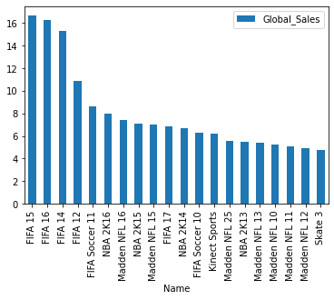

```python
sports_games.sort_values(by ='Global_Sales' , ascending = False).head(20).plot(kind='bar');
```

### OR

```python
sports_games.nlargest(20 , columns = 'Global_Sales')
```

| Name | Global_Sales |
| --- | --- |
| FIFA 15 | 16.67 |
| FIFA 16 | 16.26 |
| FIFA 14 | 15.30 |
| FIFA 12 | 10.88 |
| FIFA Soccer 11 | 8.61 |
| NBA 2K16 | 7.94 |
| Madden NFL 16 | 7.42 |
| NBA 2K15 | 7.06 |
| Madden NFL 15 | 6.97 |
| FIFA 17 | 6.86 |
| NBA 2K14 | 6.72 |
| FIFA Soccer 10 | 6.25 |
| Kinect Sports | 6.24 |
| Madden NFL 25 | 5.54 |
| NBA 2K13 | 5.48 |
| Madden NFL 13 | 5.43 |
| Madden NFL 10 | 5.20 |
| Madden NFL 11 | 5.07 |
| Madden NFL 12 | 4.94 |
| Skate 3 | 4.76 |

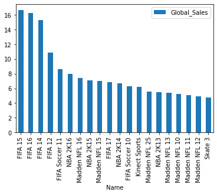

```python
sports_games.nlargest(20 , columns = 'Global_Sales').plot(kind = 'bar');
```

💥➖💥➖💥➖💥➖💥➖💥➖💥➖💥➖💥➖💥➖💥➖💥➖💥➖💥➖💥➖💥➖💥➖💥➖💥➖💥➖💥➖